# Prediction Assignment

Clement Bely

1 juillet 2020

## Load packages

I load the main packages that I will need during the project.

```r
library(AppliedPredictiveModeling)
library(caret)
library(pgmm)
library(rpart)
library(gbm)
library(lubridate)
library(forecast)
library(e1071)
library(dplyr)
```

```r
library(tibble)
library(rpart)
library(rpart.plot)
```

## 1) Data loading

I load the raw data from a website and then download them.

```r
train_url <- "http://d396qusza40orc.cloudfront.net/predmachlearn/pml-training.csv"
test_url  <- "http://d396qusza40orc.cloudfront.net/predmachlearn/pml-testing.csv"

train <- read.csv(url(train_url))
validation <- read.csv(url(test_url))

dim(train)
```

```
## [1] 19622   160
```

```r
dim(validation)
```

```
## [1]  20 160
```

## 2) Data Partitioning

I split the train data into training and testing samples. The training set consisits of 70% of the total train data and so the testing set consists of 30% of the total train data. For reproducibility, seed is set to 127.

```r
set.seed(127)
training_sample <- createDataPartition(y=train$classe, p=0.7, list=FALSE)
training <- train[training_sample, ]
testing <- train[-training_sample, ]

dim(training)
```

```
## [1] 13737   160
```

```r
dim(testing)
```

```
## [1] 5885  160
```

```r
names(training)
```

```
##   [1] "X"                        "user_name"
##   [3] "raw_timestamp_part_1"     "raw_timestamp_part_2"
##   [5] "cvtd_timestamp"           "new_window"
##   [7] "num_window"               "roll_belt"
##   [9] "pitch_belt"               "yaw_belt"
##  [11] "total_accel_belt"         "kurtosis_roll_belt"
##  [13] "kurtosis_picth_belt"      "kurtosis_yaw_belt"
##  [15] "skewness_roll_belt"       "skewness_roll_belt.1"
##  [17] "skewness_yaw_belt"        "max_roll_belt"
##  [19] "max_picth_belt"           "max_yaw_belt"
##  [21] "min_roll_belt"            "min_pitch_belt"
##  [23] "min_yaw_belt"             "amplitude_roll_belt"
##  [25] "amplitude_pitch_belt"     "amplitude_yaw_belt"
##  [27] "var_total_accel_belt"     "avg_roll_belt"
##  [29] "stddev_roll_belt"         "var_roll_belt"
```

[output cut: 65 more lines]

```r
summary(training$classe)
```

```
##    A    B    C    D    E
## 3906 2658 2396 2252 2525
```

## 3) Identify variables that are non-zero

I select only features (variables) that are non-zero in the validation data set.

```r
all_zero_colnames <- sapply(names(validation), function(x) all(is.na(validation[,x])==TRUE))
nznames <- names(all_zero_colnames)[all_zero_colnames==FALSE]
nznames <- nznames[-(1:7)]
nznames <- nznames[1:(length(nznames)-1)]
```

The final model will be fit using the following variables:

```r
nznames
```

```
##  [1] "roll_belt"            "pitch_belt"           "yaw_belt"
##  [4] "total_accel_belt"     "gyros_belt_x"         "gyros_belt_y"
##  [7] "gyros_belt_z"         "accel_belt_x"         "accel_belt_y"
## [10] "accel_belt_z"         "magnet_belt_x"        "magnet_belt_y"
## [13] "magnet_belt_z"        "roll_arm"             "pitch_arm"
## [16] "yaw_arm"              "total_accel_arm"      "gyros_arm_x"
## [19] "gyros_arm_y"          "gyros_arm_z"          "accel_arm_x"
## [22] "accel_arm_y"          "accel_arm_z"          "magnet_arm_x"
## [25] "magnet_arm_y"         "magnet_arm_z"         "roll_dumbbell"
## [28] "pitch_dumbbell"       "yaw_dumbbell"         "total_accel_dumbbell"
## [31] "gyros_dumbbell_x"     "gyros_dumbbell_y"     "gyros_dumbbell_z"
## [34] "accel_dumbbell_x"     "accel_dumbbell_y"     "accel_dumbbell_z"
## [37] "magnet_dumbbell_x"    "magnet_dumbbell_y"    "magnet_dumbbell_z"
## [40] "roll_forearm"         "pitch_forearm"        "yaw_forearm"
## [43] "total_accel_forearm"  "gyros_forearm_x"      "gyros_forearm_y"
## [46] "gyros_forearm_z"      "accel_forearm_x"      "accel_forearm_y"
## [49] "accel_forearm_z"      "magnet_forearm_x"     "magnet_forearm_y"
## [52] "magnet_forearm_z"
```

## 4) Cross-validation technique

The Cross-validation technique assesses how the results of a statistical analysis will generalize to an independent data set. In 3-fold cross-validation, the original sample is randomly partitioned into 3 equal sized sub-samples. A single sample is retained for validation and the other sub-samples are used as training data. The process is repeated 3 times and the results from the folds are averaged. Thus, for that project, I use cross-validation with the training sample in order to improve the accuracy of the predictive model. The cross-validation technique is done for each model with K = 3.

```r
fitControl <- trainControl(method='cv', number = 3)
```

## 5) Main steps for model building and evaluating the accuary

I’m going to use 3 different model algorithms and then look to see which provides the best out-of-sample accuracy. The three model types I’m going to test are the following ones : Decision trees with CART (rpart), Stochastic gradient boosting trees (gbm) and Random forest decision trees (rf). I use the cross-validation technique within the training partition to improve the model fit and then do an out-of-sample test with the testing partition. Indeed, the model fit using the training data is tested against the testing data. Predicted values for the testing data are then compared to the actual values. This allows forecasting the accuracy and overall out-of-sample error, which indicate how well the model will perform with other data.

## 6) Decision Tree Model

Run/train the model and save it :

```r
model_cart <- train(
    classe ~ .,
    data=training[, c('classe', nznames)],
    trControl=fitControl,
    method='rpart'
  )
save(model_cart, file='./ModelFitCART.RData')
```

Results of the model on the testing data and plot it :

```r
predCART <- predict(model_cart, newdata=testing)
cmCART <- confusionMatrix(predCART, testing$classe)
cmCART
```

```
## Confusion Matrix and Statistics
##
##           Reference
## Prediction    A    B    C    D    E
##          A 1517  493  475  435  171
##          B   23  388   28  183  158
##          C  130  258  523  346  277
##          D    0    0    0    0    0
##          E    4    0    0    0  476
##
## Overall Statistics
##
##                Accuracy : 0.4935
##                  95% CI : (0.4806, 0.5063)
##     No Information Rate : 0.2845
##     P-Value [Acc > NIR] : < 2.2e-16
##
##                   Kappa : 0.3374
##
##  Mcnemar's Test P-Value : NA
##
## Statistics by Class:
##
##                      Class: A Class: B Class: C Class: D Class: E
## Sensitivity            0.9062  0.34065  0.50975   0.0000  0.43993
## Specificity            0.6262  0.91740  0.79193   1.0000  0.99917
## Pos Pred Value         0.4908  0.49744  0.34094      NaN  0.99167
## Neg Pred Value         0.9438  0.85289  0.88439   0.8362  0.88788
## Prevalence             0.2845  0.19354  0.17434   0.1638  0.18386
## Detection Rate         0.2578  0.06593  0.08887   0.0000  0.08088
## Detection Prevalence   0.5252  0.13254  0.26066   0.0000  0.08156
## Balanced Accuracy      0.7662  0.62903  0.65084   0.5000  0.71955
```

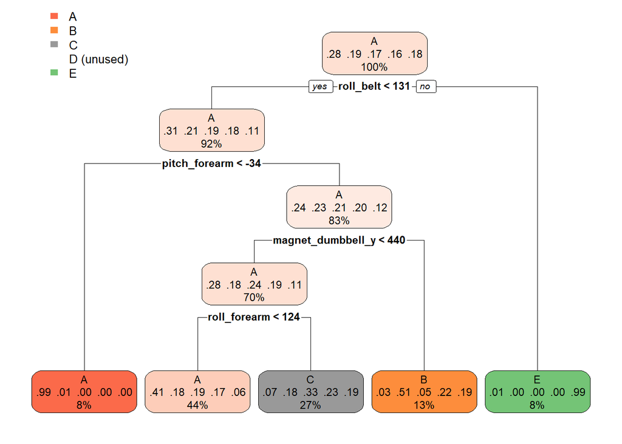

```r
rpart.plot(model_cart$finalModel, roundint=FALSE)
```

The accuracy of the Decision Tree Model, which is 0.49, is limited.

## 7) Gradient Boosting Model

Run/train the model and save it :

```r
model_gbm <- train(
  classe ~ .,
  data=training[, c('classe', nznames)],
  trControl=fitControl,
  method='gbm'
)
save(model_gbm, file='./ModelFitGBM.RData')
```

Results of the model on the testing data and plot it :

```r
predGBM <- predict(model_gbm, newdata=testing)
cmGBM <- confusionMatrix(predGBM, testing$classe)
cmGBM
```

```
## Confusion Matrix and Statistics
##
##           Reference
## Prediction    A    B    C    D    E
##          A 1646   33    0    3    2
##          B   22 1074   30    4   10
##          C    3   31  987   25    3
##          D    3    0    7  926   19
##          E    0    1    2    6 1048
##
## Overall Statistics
##
##                Accuracy : 0.9653
##                  95% CI : (0.9603, 0.9699)
##     No Information Rate : 0.2845
##     P-Value [Acc > NIR] : < 2.2e-16
##
##                   Kappa : 0.9561
##
##  Mcnemar's Test P-Value : 9.609e-05
##
## Statistics by Class:
##
##                      Class: A Class: B Class: C Class: D Class: E
## Sensitivity            0.9833   0.9429   0.9620   0.9606   0.9686
## Specificity            0.9910   0.9861   0.9872   0.9941   0.9981
## Pos Pred Value         0.9774   0.9421   0.9409   0.9696   0.9915
## Neg Pred Value         0.9933   0.9863   0.9919   0.9923   0.9930
## Prevalence             0.2845   0.1935   0.1743   0.1638   0.1839
## Detection Rate         0.2797   0.1825   0.1677   0.1573   0.1781
## Detection Prevalence   0.2862   0.1937   0.1782   0.1623   0.1796
## Balanced Accuracy      0.9871   0.9645   0.9746   0.9773   0.9834
```

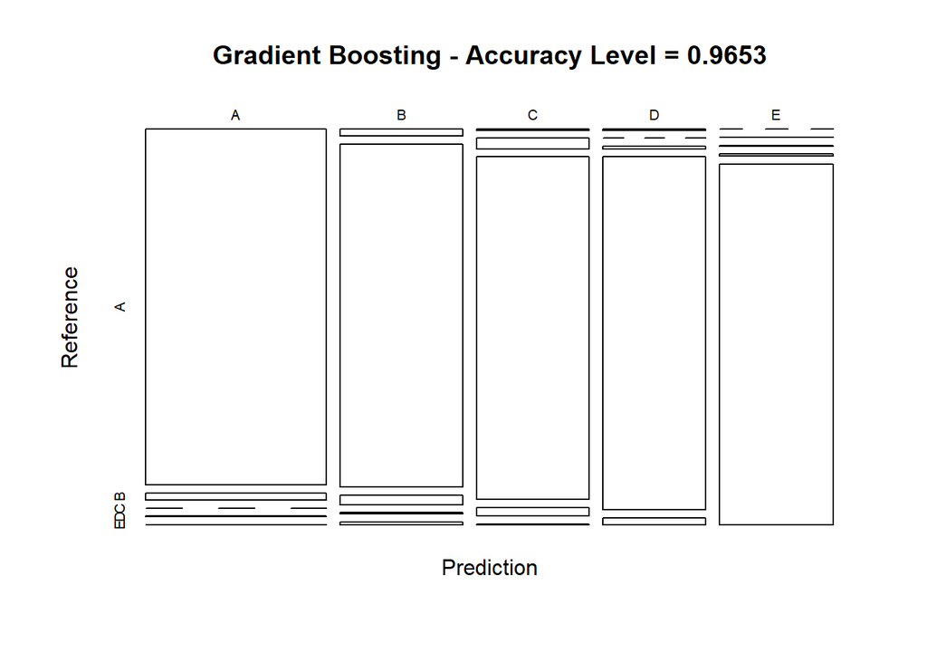

```r
plot(cmGBM$table, col = cmGBM$byClass,
     main = paste("Gradient Boosting - Accuracy Level =",
                  round(cmGBM$overall['Accuracy'], 4)))
```

The accuracy of the Gradient Boosting Model, which is 0.96, is very good.

## 8) Random Forest Model

Run/train the model and save it :

```r
model_rf <- train(
  classe ~ .,
  data=training[, c('classe', nznames)],
  trControl=fitControl,
  method='rf',
  ntree=100
)
save(model_rf, file='./ModelFitRF.RData')
```

Results of the model on the testing data and plot it :

```r
predRF <- predict(model_rf, newdata=testing)
cmRF <- confusionMatrix(predRF, testing$classe)
cmRF
```

```
## Confusion Matrix and Statistics
##
##           Reference
## Prediction    A    B    C    D    E
##          A 1672    5    0    1    0
##          B    2 1130    2    0    1
##          C    0    4 1021   12    0
##          D    0    0    3  950    4
##          E    0    0    0    1 1077
##
## Overall Statistics
##
##                Accuracy : 0.9941
##                  95% CI : (0.9917, 0.9959)
##     No Information Rate : 0.2845
##     P-Value [Acc > NIR] : < 2.2e-16
##
##                   Kappa : 0.9925
##
##  Mcnemar's Test P-Value : NA
##
## Statistics by Class:
##
##                      Class: A Class: B Class: C Class: D Class: E
## Sensitivity            0.9988   0.9921   0.9951   0.9855   0.9954
## Specificity            0.9986   0.9989   0.9967   0.9986   0.9998
## Pos Pred Value         0.9964   0.9956   0.9846   0.9927   0.9991
## Neg Pred Value         0.9995   0.9981   0.9990   0.9972   0.9990
## Prevalence             0.2845   0.1935   0.1743   0.1638   0.1839
## Detection Rate         0.2841   0.1920   0.1735   0.1614   0.1830
## Detection Prevalence   0.2851   0.1929   0.1762   0.1626   0.1832
## Balanced Accuracy      0.9987   0.9955   0.9959   0.9920   0.9976
```

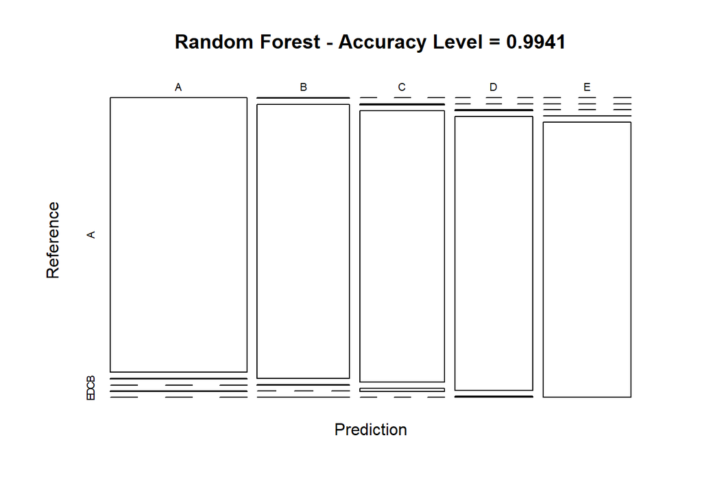

```r
plot(cmRF$table, col = cmRF$byClass,
     main = paste("Random Forest - Accuracy Level =",
                  round(cmRF$overall['Accuracy'], 4)))
```

The accuracy of the Random Forest Model, which is 0.99, is also very good.

## 9) Comparaison of models

Sum up of accuracy of the three types of models :

```r
AccuracyResults <- data.frame(
  Model = c('CART', 'GBM', 'RF'),
  Accuracy = rbind(cmCART$overall[1], cmGBM$overall[1], cmRF$overall[1])
)
AccuracyResults
```

```
##   Model  Accuracy
## 1  CART 0.4934579
## 2   GBM 0.9653356
## 3    RF 0.9940527
```

Based on an assessment of these 3 model fits and out-of-sample results, it looks like both gradient boosting and random forests outperform the decision tree model, with random forests being slightly more accurate.

The next step in modeling could be to create an ensemble model of these three model results, however, given the high accuracy of the random forest model, this process is not necessary for that project. I accept the random forest model as the champion (best model) and move on to prediction in the validation sample.

## 10) Prediction

To finish, I’m going to use the validation data sample to predict a classe for each of the 20 observations.

```r
predValidation <- predict(model_rf, newdata=validation)
ValidationPredictionResults <- data.frame(
  problem_id=validation$problem_id,
  predicted=predValidation
)
```

The results of the predicted class are :

```r
print(ValidationPredictionResults)
```

```
##    problem_id predicted
## 1           1         B
## 2           2         A
## 3           3         B
## 4           4         A
## 5           5         A
## 6           6         E
## 7           7         D
## 8           8         B
## 9           9         A
## 10         10         A
## 11         11         B
## 12         12         C
## 13         13         B
## 14         14         A
## 15         15         E
## 16         16         E
## 17         17         A
## 18         18         B
## 19         19         B
## 20         20         B
```